# 上級マクロ経済学II

第7回 人口動態と社会保障

Author

荻巣嘉高

# 1 人口動態

## 人口の増減

- 日本の問題の一つが人口減少
  - マクロ的には生産要素の減少
    - ダイレクトに生産能力を引き下げる．

図出所：国立社会保障・人口問題研究所「日本の将来推計人口（令和5年推計）」

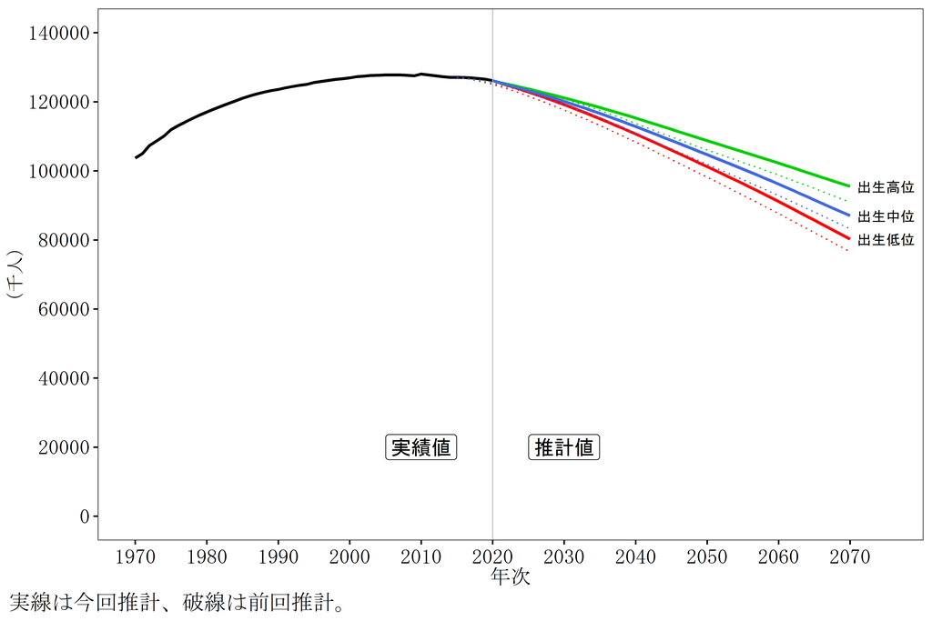

## 人口の力学

- 出生率（人口一人当たりの新生児数）：$f$
- 死亡率：$d$

人の流出入がないと仮定すれば，人口$N_t$は，

$$N_{t+1} = (f - d) N_t$$

- 少子化は$f \downarrow$
- 高齢化（長寿化）は$d \downarrow$

ネットで減少しているので，$f$の低下が相対的に大きい．

- それでも，名目上は人の減りはそこまで多くない？

## 人口の「中身」

- もう一つの本質的に重要なポイントは，人口の分布．
- 深刻な**労働力人口**の減少を招いている．
  - しかも避けられない．

図出所：国立社会保障・人口問題研究所「日本の将来推計人口（令和5年推計）」

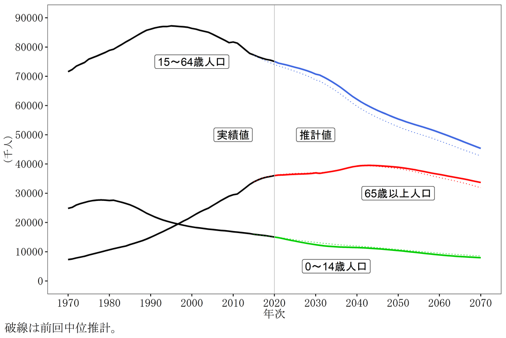

## 合計特殊出生率

人口を増やすためには，出生数を上げるのが必須．

- 1.57ショック（1990年）以降，種々の少子化対策プランを打ち出し．
  - エンゼルプラン（1994年）を起点として乱れ打ち．

図出所：国立社会保障・人口問題研究所「日本の将来推計人口（令和5年推計）」

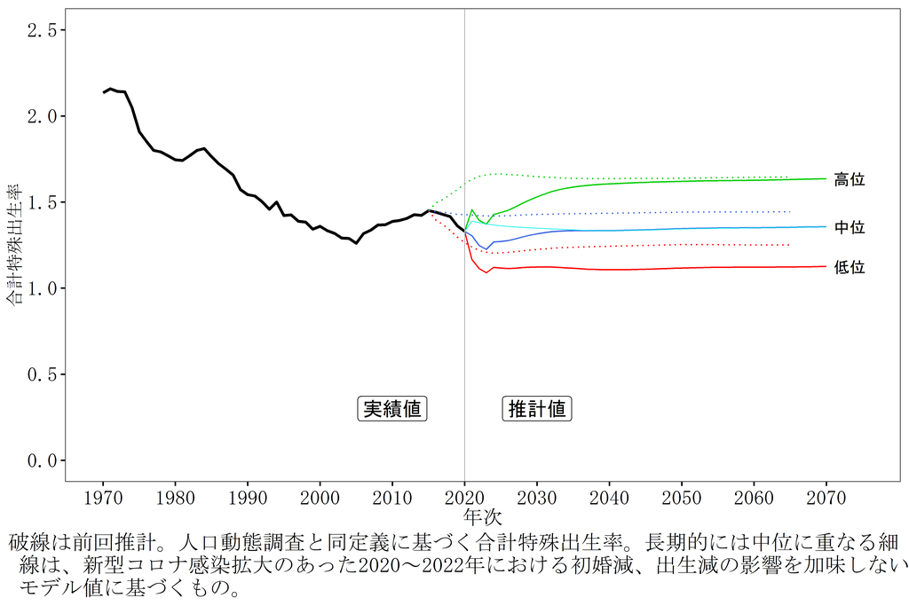

## 政策の効果

- 主なポイントは
  - ワーク・ライフ・バランスへの配慮
  - 資金援助：現金給付（子ども手当），教育無償化、結婚・出生支援．
- しかし歯止めはかかっていない．
  - なにもしないよりはましになっているのかもしれないが．

## 人口構造がもたらす問題

- 生産能力
  - 貯蓄構造の変化
- 年金の維持可能性
  - 社会保障の基盤

出生率を決定づけるメカニズムは何か？

- マクロモデルでの出生率の内生化

# 2 年金

## 年金の方式

- **積立方式**
  - 年金を納めた人の資金が運用されて，その人が老年期になったときに支給される．
- **賦課方式**
  - 若年世代の人の納めた年金が，その時の老年世代へ支給される．
- たいていの国はミックス．
  - 日本もミックス．

## 年金概念図

[figure not shown]

## 積立 vs 賦課

- 基本的に，積み立て方式は中立な制度設計になっている．
  - 家計の行動に対して影響は出てこない．
- 賦課方式は消費者の行動を変化させうる．
  - 貯蓄の減少を招くため，**動学的効率性の議論**と絡む．
  - 人口成長率が高いと有利．

人口成長率$n$のときの，OLGの設定で比較する．

## 積立方式：設定

- 若年期に年金を$\tau_t$だけ納め，年金基金が運用し，老年期に$b_t$だけ返される．
- 2期の予算制約は
  $$\begin{aligned}
  c_t^{\textrm{y}} + s_t + \tau_t &= w \\
  c_{t+1}^{\textrm{o}} &= (1+r) s_t + b_{t+1} \\
  b_{t+1} &= (1+r) \tau_t
  \end{aligned}$$

## 積立方式：生涯予算制約

生涯予算制約は，
$$c_t^{\textrm{y}} + \frac{c_{t+1}^{\textrm{o}}}{1+r} = w$$

- 一般的なOLGから変化なし．
- 行動（消費計画）も変化なし．

## 積立方式：貯蓄量

経済での総貯蓄量は，
$$S_t = (s_t + \tau_t) L_t$$

- 年金$\tau_t$がない場合と貯蓄総量は変わらない．
  - 年金がない場合に1000万円貯蓄する家計があるとする．
  - 年金が導入されて$\tau_t$で300万円徴収されるとすれば，残りの700万円を貯蓄する．

## 賦課方式：設定

- 若年世代が年金を$\tau$だけ納め，それがそのまま老年世代に給付される．
- 2期の予算制約は，
  $$\begin{aligned}
  c_t^{\textrm{y}} + s_t + \tau_t &= w \\
  c_{t+1}^{\textrm{o}} &= (1+r) s_t + b_{t+1} \\
  b_{t+1} &= (1+n) \tau_{t+1}
  \end{aligned}$$
- 年金の支給バランスは，$b_{t+1} L_{t} = \tau_{t+1} L_{t+1} \Longrightarrow b_{t+1} = (1+n) \tau_{1+t}$

## 賦課方式：生涯予算制約

年金支給額が常に一定（$\tau_{t} = \tau ~ \forall t$）だと仮定すると，生涯予算制約は，
$$c_t^{\textrm{y}} + \frac{c_{t+1}^{\textrm{o}}}{1+r} = w + \frac{n - r}{1+r} \tau$$

- $n\neq r$ならば，家計の予算制約が変化．
  - 特に，$n > r$ならば，生涯予算制約のうち，可処分所得は増加する．
    - 人口増加社会で賦課方式年金を導入することに対する，ひとつの正当化．
- 家計の貯蓄行動も変化．

## 賦課方式：貯蓄量

経済の総貯蓄量は
$$S_t = s_t L_t$$

- 年金は運用されないため，民間の貯蓄のみが経済の貯蓄に回る．
  - 可処分所得$w_t - \tau$から$c_t$，$s_t$に振り分けを行っているので，年金導入前と比較すれば貯蓄は減る．
  - $K_{t+1}=I_t = S_t$なので，経済が動学的非効率の場合にはパレート改善になりうる．

## 近年の議論

- 日本では人口減少社会なので，$n$は下落．
  - 賦課方式が若年世代の重荷になっている．
- 移行の議論はあるが，痛みを伴う．
  - 積立→賦課は誰も損をしないようにできるが，賦課→積立は移行世代において必ず支給額の減少を招く．
    - 納めた額に見合った年金をもらえない世代がある．
    - それでも改革を進めた国もある（e.g., チリ）．

人口成長を誘導するのがひとまずの処方箋．

# 3 出生モデル

## 観測的事実

- 経済成長と出生率は負の相関
  - 子供を育てるにはお金がかかる
  - 子供が望ましいものと考えれば，所得効果によって上昇しそうだが，事実は逆．

Becker (1960)やBecker and Lewis (1973)らの分析へ

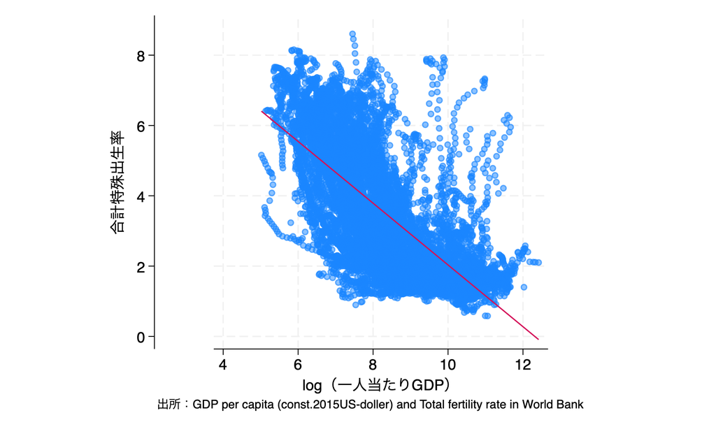

## 子供の質と量

ここでは，Becker and Lewis (1973)タイプのモデルを紹介．

- 橘木・木村 (2008) に日本語での解説があるので，それを参考にしています．

重要なポイントは，出生の意思決定にはトレードオフが存在する点．

- 質（quality）
- 量（quantity）

取り扱うモデルは質と量のトレードオフモデルとかいわれる．

## 質と量のトレードオフ：静学的なアプローチ

- 効用関数では，子供の教育水準が高ければHappyかつ子供の数が多くてもHappyだと想定されている．

予算制約は，
$$I = c + p q n$$

- $c$：消費，$n$：子供の数，$q$：子供の質（教育投資），$p$：教育の価格，$I$：所得
- 所得，消費，教育の価格が一定だとすれば，質$q$を上げるには，$n$を減らす必要がある．

## 動学的なアプローチ

”質”の議論は人的資本理論との接続される．

Moav (2005) および橘木・木村 (2008) を参考にして，次のようなOLGでの問題設定を考えてみよう．

$$\begin{aligned}
U &= \alpha \log c_t + \beta \log n_t + \gamma \log h_{t+1} \\
\textrm{s.t. } c_t &= \left(1 - z n_t - e_t n_t /h_t \right) w h_t \\
h_{t+1} &= (\mu + e_t)^{\epsilon}, \hspace{12pt} \epsilon \in (0,1), ~ \mu > 0
\end{aligned}$$

- 可処分時間1単位を，子供の養育（$z$）と教育（$e_t$）に割り当てる．
  - 子供1人を育てるために必要な時間が$z$．
  - 親の人的資本$h_t$が高ければ，教育は時間が節約できる．

## 家計の最適化

$$\begin{aligned}
n_t &= \frac{(\beta - \epsilon \gamma) h_t}{(\alpha + \beta)(z h_t - \mu)}& \\
e_t &= \frac{\epsilon \gamma z h_t - \beta \mu}{\beta - \epsilon \gamma} \\
c_t &= \frac{\alpha w h_t }{\alpha + \beta} \\
\end{aligned}$$

- $h_t < \frac{\beta \mu}{\epsilon \gamma z}\equiv \bar{h}$のとき，$e_t=0$

## 資本蓄積

$$h_t = \left\{ \begin{aligned}
&\mu^\epsilon & \text{if }h_t < \bar{h} \\
&\left(\mu + \frac{\epsilon \gamma z h_t - \beta \mu}{\beta - \epsilon \gamma} \right)^\epsilon &\text{if }h_t \ge \bar{h}
\end{aligned}\right.$$

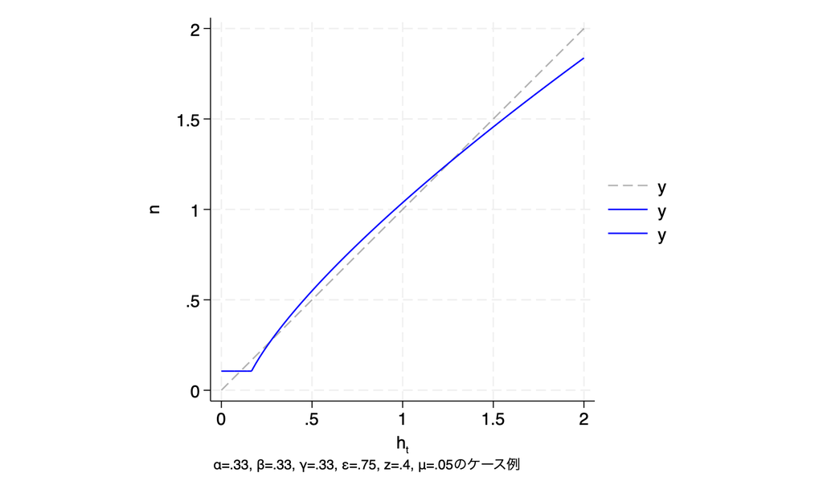

## 子供の数の動学

- 子供の数も定常状態に応じて複数存在しうる．
- 経済の発展とともに，親の能力$h_t$が上昇．
  - 子供の教育費用は相対的に安くなる．
  - 一方，育児費用は変わらない．
  - （効用で測って）教育の収益率の方が良いので，子供の数を減らし，教育を重視するようになる．

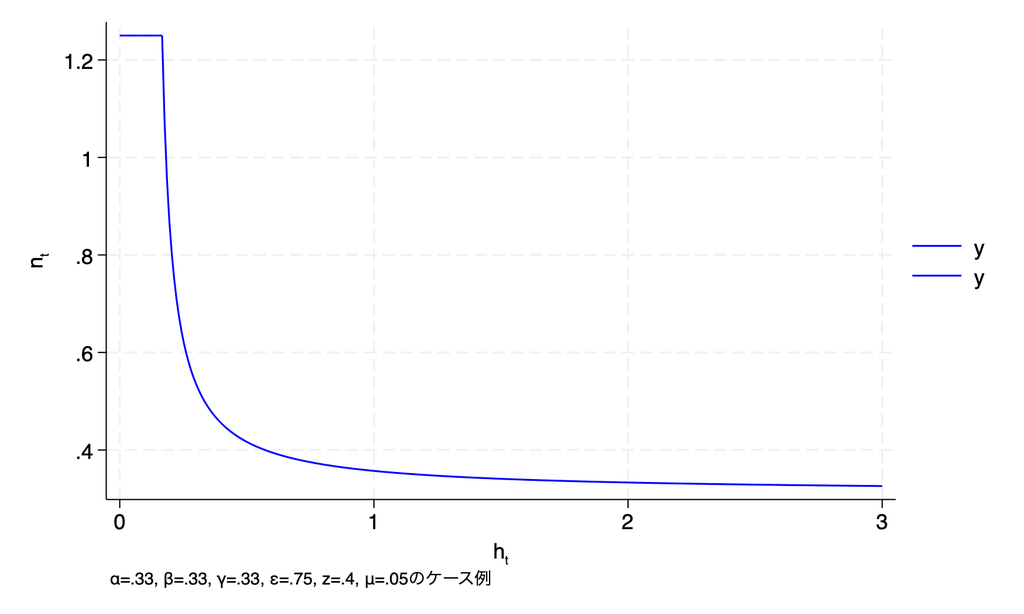

## 参考文献

- Becker, G. S. and H. G. Lewis (1960) “An economic analysis of fertility,” in A. J. Coale ed., *Demographic and Economic Change in Developed Countries*, Princeton University Press.
- Becker, G. S. and H. G. Lewis (1973) “On the interaction between the quantity and quality of children,” *Journal of Political Economy*, 81.
- 橘木俊詔・木村匡子 (2008) 「家族の経済学：お金と絆のせめぎあい」NTT出版